# Practical Machine Learning Assignment

## Introduction

In this assignment, data from the [Human Activity Recognition](http://web.archive.org/web/20161224072740/http:/groupware.les.inf.puc-rio.br/har) is used in machine learning using a random forest model. The model is derived from a training set, which is further split into two subsets used for training and for k-fold cross validation. Then the model is applied to a test set of 20 samples and correctly predicts the outcome variable.

## Getting and Cleaning Data

First, the necessary libraries for the assignment are loaded and a seed is set for reproducibility.

```r
library(lattice)
library(ggplot2)
library(foreach)
library(iterators)
library(caret)
library(rattle)
library(dplyr)
library(parallel)
library(doParallel)
library(pryr)
set.seed(1235)
```

The data is loaded and some exploratory analysis is done by looking at the dimensions of the data.

```r
train <- read.csv("pml-training.csv", na.strings=c("NA"))
test <- read.csv("pml-testing.csv", na.strings=c("NA"))
dim(train)
```

```
## [1] 19622   160
```

```r
dim(test)
```

```
## [1]  20 160
```

## Clean the data

Check if in the observations are present NA values or missing OBS that can raise errors/bias during the model training.

```r
sum(complete.cases(train))
```

```
## [1] 406
```

Too few observation to have a correct training.

### Eliminate the columns with NA/missing values

Let’s see colnames

```r
colnames(train)
```

```
##   [1] "X"                        "user_name"
##   [3] "raw_timestamp_part_1"     "raw_timestamp_part_2"
##   [5] "cvtd_timestamp"           "new_window"
##   [7] "num_window"               "roll_belt"
##   [9] "pitch_belt"               "yaw_belt"
##  [11] "total_accel_belt"         "kurtosis_roll_belt"
##  [13] "kurtosis_picth_belt"      "kurtosis_yaw_belt"
##  [15] "skewness_roll_belt"       "skewness_roll_belt.1"
##  [17] "skewness_yaw_belt"        "max_roll_belt"
##  [19] "max_picth_belt"           "max_yaw_belt"
##  [21] "min_roll_belt"            "min_pitch_belt"
##  [23] "min_yaw_belt"             "amplitude_roll_belt"
##  [25] "amplitude_pitch_belt"     "amplitude_yaw_belt"
##  [27] "var_total_accel_belt"     "avg_roll_belt"
##  [29] "stddev_roll_belt"         "var_roll_belt"
```

[output cut: 65 more lines]

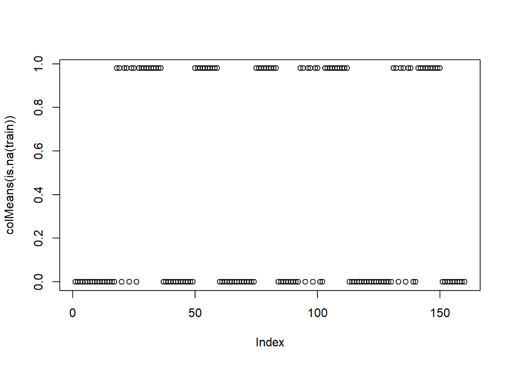

```r
plot(colMeans(is.na(train)))
```

There are columns with a lot of missing values.

We will reatain only the columns without NA values

First covert all the data in NUMERIC form to coerce the empty factor to NA

```r
trainClasse = train$classe
trainRaw = train[, sapply(train, is.numeric)]
testRaw = test[, sapply(test, is.numeric)]
```

Remove columns with NA values

```r
trainFilter <- trainRaw[, colSums(is.na(trainRaw)) == 0]
# Attach Classe variable
trainFilter$classe = trainClasse
testFilter <- testRaw[, colSums(is.na(testRaw)) == 0]
```

Dimension

```r
dim(trainFilter)
```

```
## [1] 19622    57
```

```r
dim(testFilter)
```

```
## [1] 20 57
```

Removing other unuseful columns like username, timestamp and ID

```r
unwanted = !grepl("X|timestamp", colnames(trainFilter))
cols = colnames(trainFilter)[unwanted]
trainFilter = trainFilter %>%
  select(cols)
unwanted = !grepl("X|timestamp", colnames(testFilter))
cols = colnames(testFilter)[unwanted]
testFilter = testFilter %>%
  select(cols)
```

Get dimension of the filtered dataset

```r
dim(trainFilter)
```

```
## [1] 19622    54
```

```r
dim(testFilter)
```

```
## [1] 20 54
```

## Slice the data

```r
set.seed(1202435)
inTrain <- createDataPartition(trainFilter$classe, p=0.70, list=F)
trainData <- trainFilter[inTrain, ]
validationData <- trainFilter[-inTrain, ]
dim(trainData)
```

```
## [1] 13737    54
```

# Data modeling

We will fit a model using **Random Forest** for several reasons:

1. With tree-based models, **you can safely ignore** predictors correlation issues
2. Zero- and Near Zero-Variance Predictors **does not** imply on tree-based models
3. As each feature is processed separately, and the possible splits of the data don’t depend on scaling, no preprocessing like normalization or standardization of features is needed for decision tree algorithms.

## Random forest Model

```r
controlRf <- trainControl(method="cv", 5, allowParallel = TRUE)
modelRf <- train(classe ~ ., data=trainData, method="rf", trControl=controlRf, ntree=250)
modelRf
```

```
## Random Forest
##
## 13737 samples
##    53 predictor
##     5 classes: 'A', 'B', 'C', 'D', 'E'
##
## No pre-processing
## Resampling: Cross-Validated (5 fold)
## Summary of sample sizes: 10988, 10991, 10990, 10991, 10988
## Resampling results across tuning parameters:
##
##   mtry  Accuracy   Kappa
##    2    0.9937401  0.9920814
##   27    0.9968702  0.9960409
##   53    0.9941768  0.9926334
##
## Accuracy was used to select the optimal model using the largest value.
## The final value used for the model was mtry = 27.
```

### Performance of the model on the validation data set

```r
predict_rf <- predict(modelRf, validationData)
confusionMatrix(validationData$classe, predict_rf)
```

```
## Confusion Matrix and Statistics
##
##           Reference
## Prediction    A    B    C    D    E
##          A 1672    1    0    0    1
##          B    3 1135    1    0    0
##          C    0    2 1024    0    0
##          D    0    0    6  958    0
##          E    0    0    0    2 1080
##
## Overall Statistics
##
##                Accuracy : 0.9973
##                  95% CI : (0.9956, 0.9984)
##     No Information Rate : 0.2846
##     P-Value [Acc > NIR] : < 2.2e-16
##
##                   Kappa : 0.9966
##
##  Mcnemar's Test P-Value : NA
##
## Statistics by Class:
##
##                      Class: A Class: B Class: C Class: D Class: E
## Sensitivity            0.9982   0.9974   0.9932   0.9979   0.9991
## Specificity            0.9995   0.9992   0.9996   0.9988   0.9996
## Pos Pred Value         0.9988   0.9965   0.9981   0.9938   0.9982
## Neg Pred Value         0.9993   0.9994   0.9986   0.9996   0.9998
## Prevalence             0.2846   0.1934   0.1752   0.1631   0.1837
## Detection Rate         0.2841   0.1929   0.1740   0.1628   0.1835
## Detection Prevalence   0.2845   0.1935   0.1743   0.1638   0.1839
## Balanced Accuracy      0.9989   0.9983   0.9964   0.9983   0.9993
```

Very accurate model to classify **classe** feature

# Predict Test data with RF

```r
resultRf <- predict(modelRf, testFilter[, -length(names(testFilter))])
resultRf
```

```
##  [1] B A B A A E D B A A B C B A E E A B B B
## Levels: A B C D E
```

Finally the model predict the TEST data in the same way